# Student Final Grade Prediction

```python
import pandas as pd
import numpy as np
import matplotlib.pyplot as plt
import seaborn as sns
from sklearn.preprocessing import StandardScaler
from sklearn.model_selection import train_test_split
from sklearn.model_selection import RandomizedSearchCV
%matplotlib inline
```

```python
data = pd.read_csv('student-por.csv',delimiter = ';')
```

```python
data
```

|  | school | sex | age | address | famsize | Pstatus | Medu | Fedu | Mjob | Fjob | ... | famrel | freetime | goout | Dalc | Walc | health | absences | G1 | G2 | G3 |
| --- | --- | --- | --- | --- | --- | --- | --- | --- | --- | --- | --- | --- | --- | --- | --- | --- | --- | --- | --- | --- | --- |
| 0 | GP | F | 18 | U | GT3 | A | 4 | 4 | at_home | teacher | ... | 4 | 3 | 4 | 1 | 1 | 3 | 4 | 0 | 11 | 11 |
| 1 | GP | F | 17 | U | GT3 | T | 1 | 1 | at_home | other | ... | 5 | 3 | 3 | 1 | 1 | 3 | 2 | 9 | 11 | 11 |
| 2 | GP | F | 15 | U | LE3 | T | 1 | 1 | at_home | other | ... | 4 | 3 | 2 | 2 | 3 | 3 | 6 | 12 | 13 | 12 |
| 3 | GP | F | 15 | U | GT3 | T | 4 | 2 | health | services | ... | 3 | 2 | 2 | 1 | 1 | 5 | 0 | 14 | 14 | 14 |
| 4 | GP | F | 16 | U | GT3 | T | 3 | 3 | other | other | ... | 4 | 3 | 2 | 1 | 2 | 5 | 0 | 11 | 13 | 13 |
| ... | ... | ... | ... | ... | ... | ... | ... | ... | ... | ... | ... | ... | ... | ... | ... | ... | ... | ... | ... | ... | ... |
| 644 | MS | F | 19 | R | GT3 | T | 2 | 3 | services | other | ... | 5 | 4 | 2 | 1 | 2 | 5 | 4 | 10 | 11 | 10 |
| 645 | MS | F | 18 | U | LE3 | T | 3 | 1 | teacher | services | ... | 4 | 3 | 4 | 1 | 1 | 1 | 4 | 15 | 15 | 16 |
| 646 | MS | F | 18 | U | GT3 | T | 1 | 1 | other | other | ... | 1 | 1 | 1 | 1 | 1 | 5 | 6 | 11 | 12 | 9 |
| 647 | MS | M | 17 | U | LE3 | T | 3 | 1 | services | services | ... | 2 | 4 | 5 | 3 | 4 | 2 | 6 | 10 | 10 | 10 |
| 648 | MS | M | 18 | R | LE3 | T | 3 | 2 | services | other | ... | 4 | 4 | 1 | 3 | 4 | 5 | 4 | 10 | 11 | 11 |

649 rows × 33 columns

```python
#Checking for null values
data.isnull().sum()
```

```
school        0
sex           0
age           0
address       0
famsize       0
Pstatus       0
Medu          0
Fedu          0
Mjob          0
Fjob          0
reason        0
guardian      0
traveltime    0
studytime     0
failures      0
schoolsup     0
famsup        0
paid          0
activities    0
nursery       0
higher        0
internet      0
romantic      0
famrel        0
freetime      0
goout         0
Dalc          0
Walc          0
health        0
absences      0
G1            0
G2            0
G3            0
dtype: int64
```

There is no null value, So there's no need to 'Impute'... Now Let's understand a bit more about the data

```python
data.info()
```

```
<class 'pandas.core.frame.DataFrame'>
RangeIndex: 649 entries, 0 to 648
Data columns (total 33 columns):
 #   Column      Non-Null Count  Dtype
---  ------      --------------  -----
 0   school      649 non-null    object
 1   sex         649 non-null    object
 2   age         649 non-null    int64
 3   address     649 non-null    object
 4   famsize     649 non-null    object
 5   Pstatus     649 non-null    object
 6   Medu        649 non-null    int64
 7   Fedu        649 non-null    int64
 8   Mjob        649 non-null    object
 9   Fjob        649 non-null    object
```

[output cut: 25 more lines]

```python
data.describe()
```

|  | age | Medu | Fedu | traveltime | studytime | failures | famrel | freetime | goout | Dalc | Walc | health | absences | G1 | G2 | G3 |
| --- | --- | --- | --- | --- | --- | --- | --- | --- | --- | --- | --- | --- | --- | --- | --- | --- |
| count | 649.000000 | 649.000000 | 649.000000 | 649.000000 | 649.000000 | 649.000000 | 649.000000 | 649.000000 | 649.000000 | 649.000000 | 649.000000 | 649.000000 | 649.000000 | 649.000000 | 649.000000 | 649.000000 |
| mean | 16.744222 | 2.514638 | 2.306626 | 1.568567 | 1.930663 | 0.221880 | 3.930663 | 3.180277 | 3.184900 | 1.502311 | 2.280431 | 3.536210 | 3.659476 | 11.399076 | 11.570108 | 11.906009 |
| std | 1.218138 | 1.134552 | 1.099931 | 0.748660 | 0.829510 | 0.593235 | 0.955717 | 1.051093 | 1.175766 | 0.924834 | 1.284380 | 1.446259 | 4.640759 | 2.745265 | 2.913639 | 3.230656 |
| min | 15.000000 | 0.000000 | 0.000000 | 1.000000 | 1.000000 | 0.000000 | 1.000000 | 1.000000 | 1.000000 | 1.000000 | 1.000000 | 1.000000 | 0.000000 | 0.000000 | 0.000000 | 0.000000 |
| 25% | 16.000000 | 2.000000 | 1.000000 | 1.000000 | 1.000000 | 0.000000 | 4.000000 | 3.000000 | 2.000000 | 1.000000 | 1.000000 | 2.000000 | 0.000000 | 10.000000 | 10.000000 | 10.000000 |
| 50% | 17.000000 | 2.000000 | 2.000000 | 1.000000 | 2.000000 | 0.000000 | 4.000000 | 3.000000 | 3.000000 | 1.000000 | 2.000000 | 4.000000 | 2.000000 | 11.000000 | 11.000000 | 12.000000 |
| 75% | 18.000000 | 4.000000 | 3.000000 | 2.000000 | 2.000000 | 0.000000 | 5.000000 | 4.000000 | 4.000000 | 2.000000 | 3.000000 | 5.000000 | 6.000000 | 13.000000 | 13.000000 | 14.000000 |
| max | 22.000000 | 4.000000 | 4.000000 | 4.000000 | 4.000000 | 3.000000 | 5.000000 | 5.000000 | 5.000000 | 5.000000 | 5.000000 | 5.000000 | 32.000000 | 19.000000 | 19.000000 | 19.000000 |

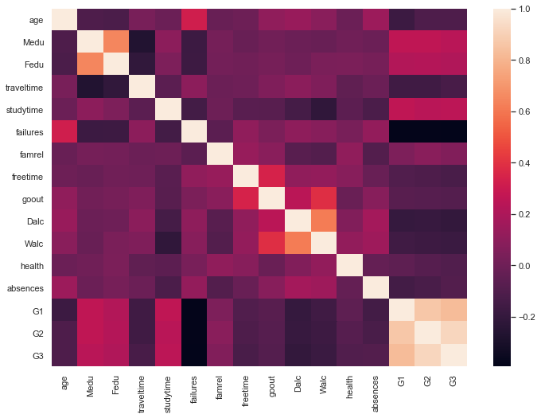

```python
sns.set(rc={'figure.figsize':(11.7,8.27)})
sns.heatmap(data.corr())
```

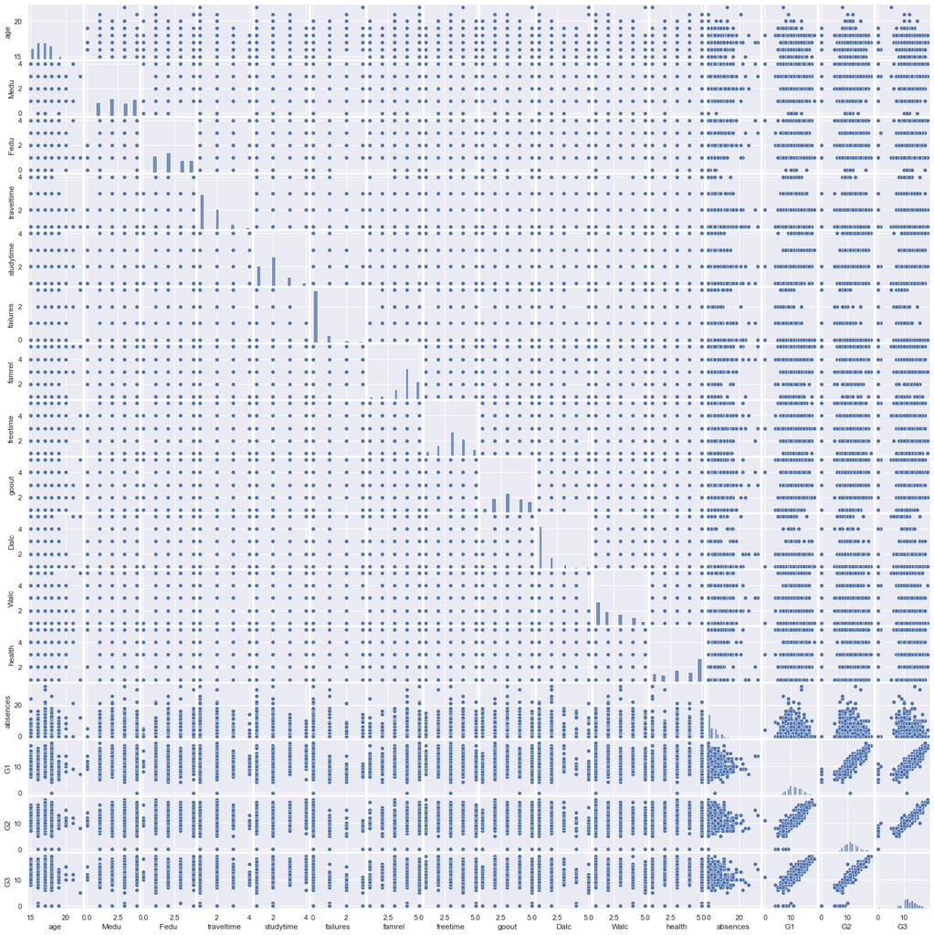

```python
g=sns.pairplot(data)
g.fig.set_size_inches(20,20)
```

It's obvious from the pairplot and heatmap that G1 and G2 are highly correlated with G3(Target) ... Lets jointplot them to understand more about the distribution

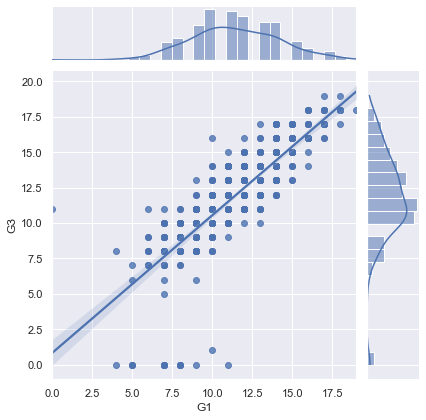

```python
sns.jointplot(x="G1",y="G3",data=data,kind='reg')
```

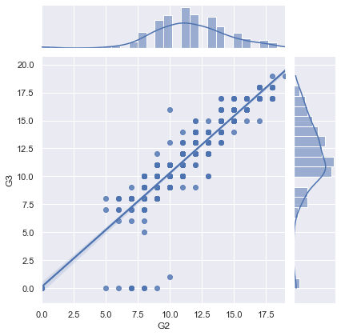

```python
sns.jointplot(x="G2",y="G3",data=data,kind='reg')
```

The Jointplot supports to the point that G1 and G2 has more relation towards our target(G3) ... Now lets breakdown the categorical features

# Exploratory data analysis

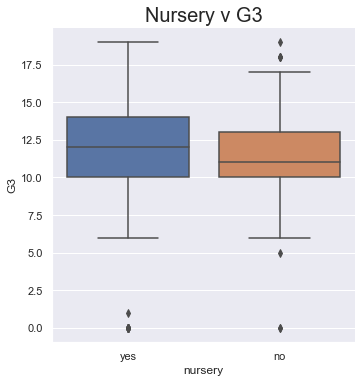

```python
plt.figure(figsize=(12,6))
sns.catplot(x="nursery", y="G3", kind="box", data=data)
plt.title('Nursery v G3', size=20)
```

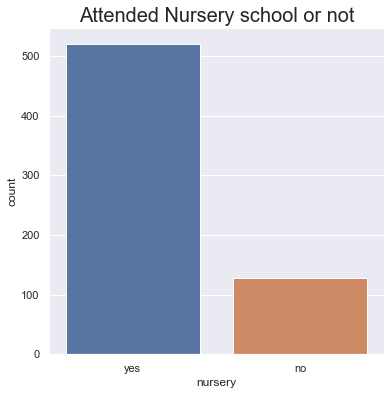

```python
plt.figure(figsize=(6,6))
sns.countplot(x='nursery',data=data)
plt.title("Attended Nursery school or not",size=20)
```

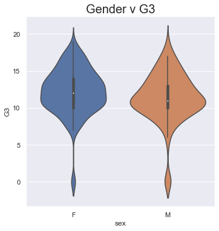

```python
plt.figure(figsize=(12,6))
sns.catplot(x="sex", y="G3", kind="violin", data=data)
plt.title('Gender v G3', size=20)
```

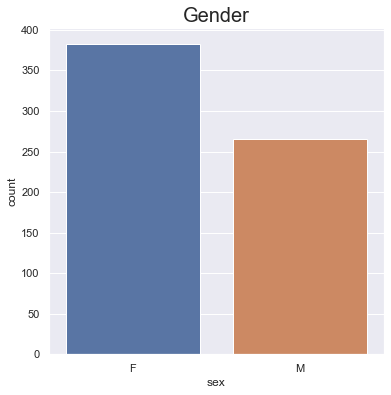

```python
plt.figure(figsize=(6,6))
sns.countplot(x='sex',data=data)
plt.title("Gender",size=20)
```

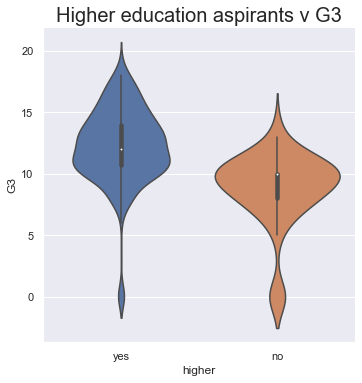

```python
plt.figure(figsize=(12,6))
sns.catplot(x="higher", y="G3", kind="violin", data=data)
plt.title('Higher education aspirants v G3', size=20)
```

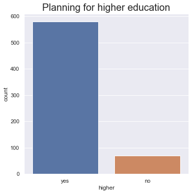

```python
plt.figure(figsize=(6,6))
sns.countplot(x='higher',data=data)
plt.title("Planning for higher education",size=20)
```

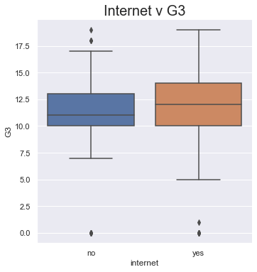

```python
plt.figure(figsize=(12,6))
sns.catplot(x="internet", y="G3", kind="box", data=data)
plt.title('Internet v G3', size=20)
```

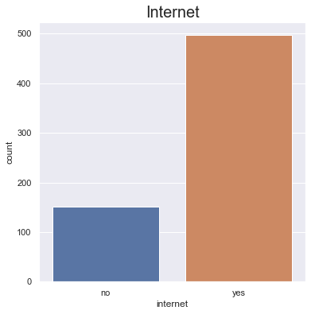

```python
plt.figure(figsize=(6,6))
sns.countplot(x='internet',data=data)
plt.title("Internet",size=20)
```

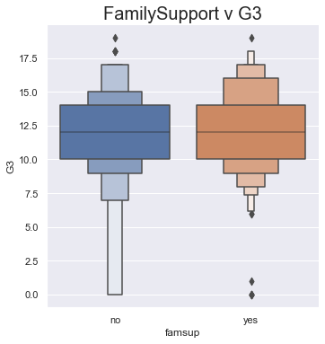

```python
plt.figure(figsize=(12,6))
sns.catplot(x="famsup", y="G3", kind="boxen", data=data)
plt.title('FamilySupport v G3', size=20)
```

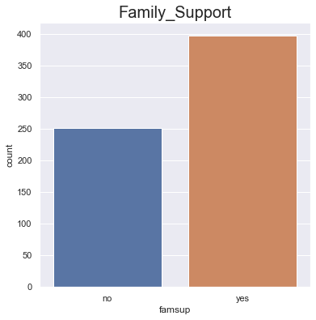

```python
plt.figure(figsize=(6,6))
sns.countplot(x='famsup',data=data)
plt.title("Family_Support",size=20)
```

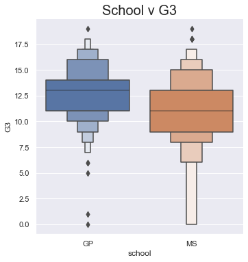

```python
plt.figure(figsize=(12,6))
sns.catplot(x="school", y="G3",kind = 'boxen',data=data)
plt.title('School v G3', size=20)
```

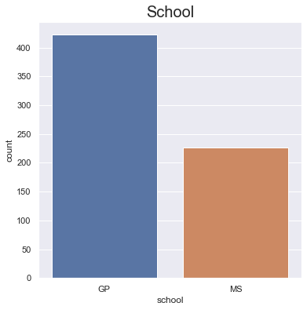

```python
plt.figure(figsize=(6,6))
sns.countplot(x='school',data=data)
plt.title("School",size=20)
```

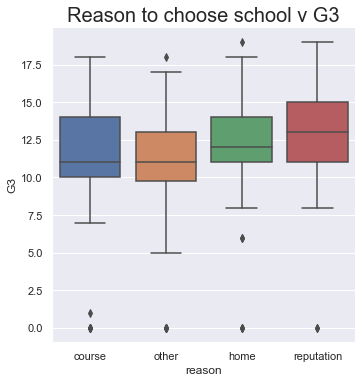

```python
plt.figure(figsize=(12,6))
sns.catplot(x="reason", y="G3",kind = 'box',data=data)
plt.title('Reason to choose school v G3', size=20)
```

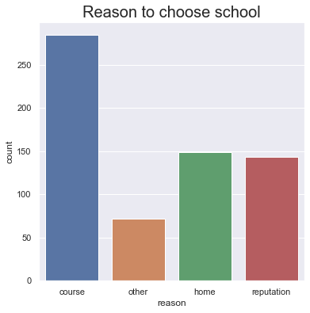

```python
plt.figure(figsize=(6,6))
sns.countplot(x='reason',data=data)
plt.title("Reason to choose school",size=20)
```

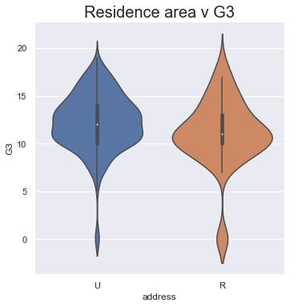

```python
plt.figure(figsize=(12,6))
sns.catplot(x="address", y="G3",kind = 'violin',data=data)
plt.title('Residence area v G3', size=20)
# U - Urban , R - Rural
```

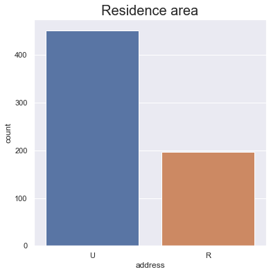

```python
plt.figure(figsize=(6,6))
sns.countplot(x='address',data=data)
plt.title("Residence area",size=20)
# U - Urban , R - Rural
```

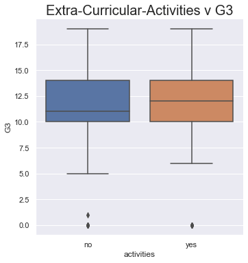

```python
plt.figure(figsize=(12,6))
sns.catplot(x="activities", y="G3", kind="box", data=data)
plt.title('Extra-Curricular-Activities v G3', size=20)
```

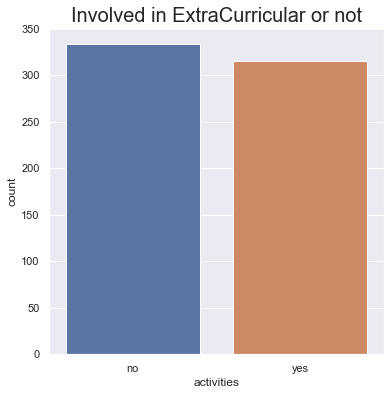

```python
plt.figure(figsize=(6,6))
sns.countplot(x='activities',data=data)
plt.title("Involved in ExtraCurricular or not",size=20)
```

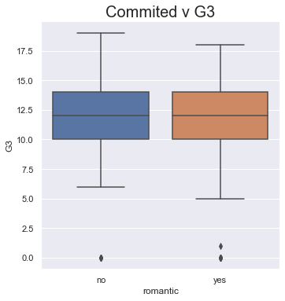

```python
plt.figure(figsize=(12,6))
sns.catplot(x="romantic", y="G3", kind="box", data=data)
plt.title('Commited v G3', size=20)
```

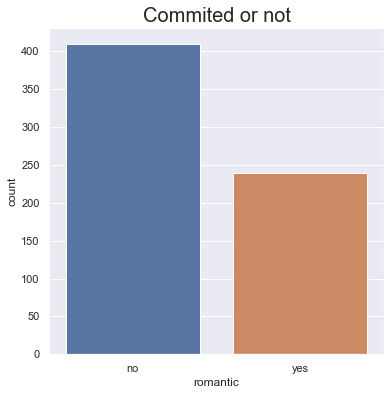

```python
plt.figure(figsize=(6,6))
sns.countplot(x='romantic',data=data)
plt.title("Commited or not",size=20)
```

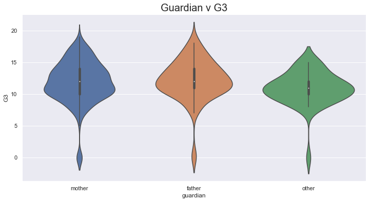

```python
plt.figure(figsize=(12,6))
sns.violinplot(x="guardian", y="G3", kind="box", data=data)
plt.title('Guardian v G3', size=20)
```

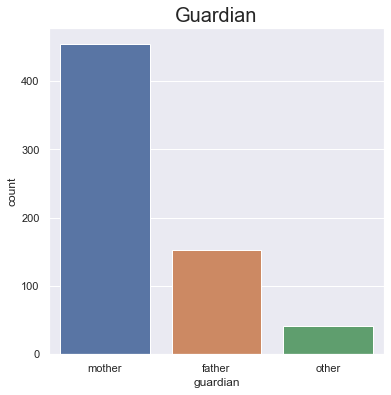

```python
plt.figure(figsize=(6,6))
sns.countplot(x='guardian',data=data)
plt.title("Guardian",size=20)
```

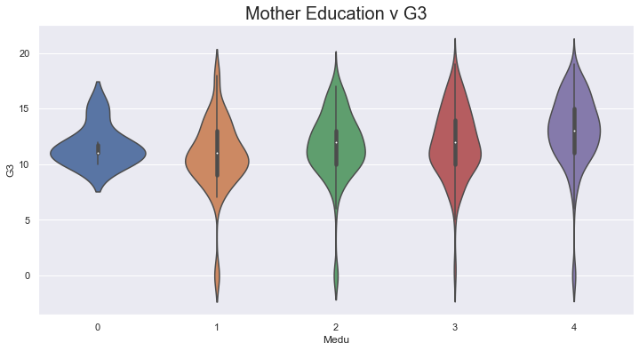

```python
plt.figure(figsize=(12,6))
sns.violinplot(x="Medu", y="G3", kind="box", data=data)
plt.title('Mother Education v G3', size=20)
#0 - none,  1 - primary education (4th grade), 2 – 5th to 9th grade, 3 – secondary education or 4 – higher education
```

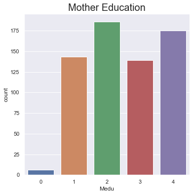

```python
plt.figure(figsize=(6,6))
sns.countplot(x='Medu',data=data)
plt.title("Mother Education",size=20)
#0 - none,  1 - primary education (4th grade), 2 – 5th to 9th grade, 3 – secondary education or 4 – higher education
```

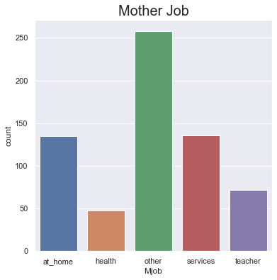

```python
plt.figure(figsize=(6,6))
sns.countplot(x='Mjob',data=data)
plt.title("Mother Job",size=20)
```

[figure not shown]

```python
plt.figure(figsize=(12,6))
sns.catplot(x="Fjob", y="G3", kind="violin", data=data)
plt.title('Mother Job v G3', size=20)
```

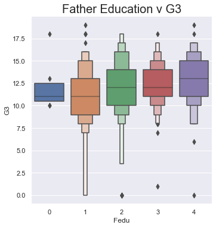

```python
plt.figure(figsize=(12,6))
sns.catplot(x="Fedu", y="G3", kind="boxen", data=data)
plt.title('Father Education v G3', size=20)
#0 - none,  1 - primary education (4th grade), 2 – 5th to 9th grade, 3 – secondary education or 4 – higher education
```

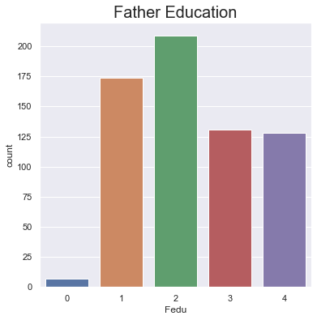

```python
plt.figure(figsize=(6,6))
sns.countplot(x='Fedu',data=data)
plt.title("Father Education",size=20)
#0 - none,  1 - primary education (4th grade), 2 – 5th to 9th grade, 3 – secondary education or 4 – higher education
```

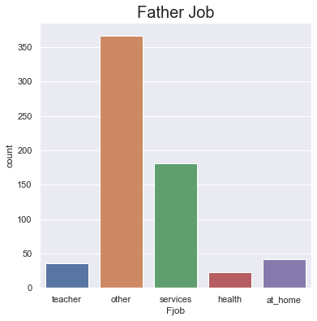

```python
plt.figure(figsize=(6,6))
sns.countplot(x='Fjob',data=data)
plt.title("Father Job",size=20)
```

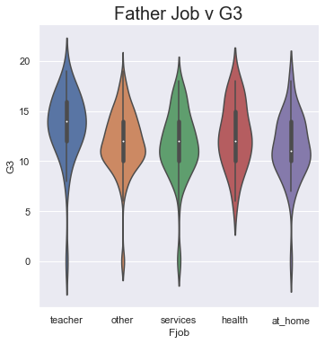

```python
plt.figure(figsize=(12,6))
sns.catplot(x="Fjob", y="G3", kind="violin", data=data)
plt.title('Father Job v G3', size=20)
```

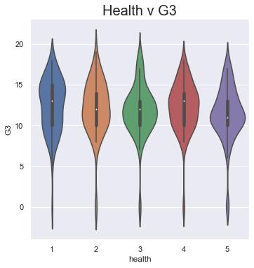

```python
plt.figure(figsize=(12,6))
sns.catplot(x="health", y="G3", kind="violin", data=data)
plt.title('Health v G3', size=20)
```

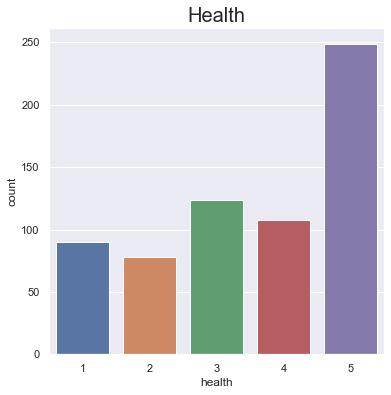

```python
plt.figure(figsize=(6,6))
sns.countplot(x='health',data=data)
plt.title("Health",size=20)
#1 - Unhealthy , 5 - Even god cant kill me
```

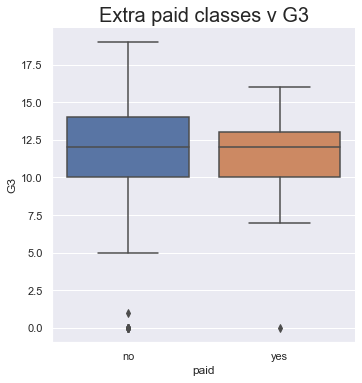

```python
plt.figure(figsize=(12,6))
sns.catplot(x="paid", y="G3", kind="box", data=data)
plt.title('Extra paid classes v G3', size=20)
```

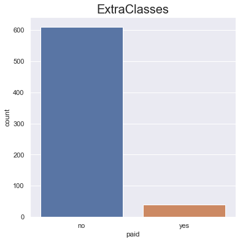

```python
plt.figure(figsize=(6,6))
sns.countplot(x='paid',data=data)
plt.title("ExtraClasses",size=20)
```

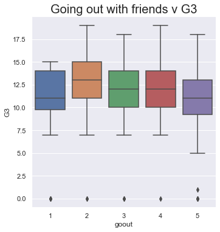

```python
plt.figure(figsize=(12,6))
sns.catplot(x="goout", y="G3", kind="box", data=data)
plt.title('Going out with friends v G3', size=20)
#1 - Not at all , 5 - Going out frequently
```

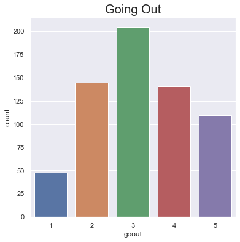

```python
plt.figure(figsize=(6,6))
sns.countplot(x='goout',data=data)
plt.title("Going Out",size=20)
#1 - Not at all , 5 - Going out frequently
```

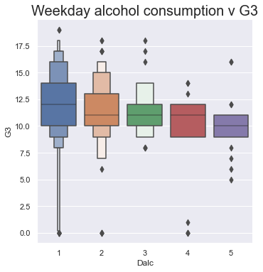

```python
plt.figure(figsize=(12,6))
sns.catplot(x="Dalc", y="G3", kind="boxen", data=data)
plt.title('Weekday alcohol consumption v G3', size=20)
#1 - Wont even touch it , 5 - Alcohol is life
```

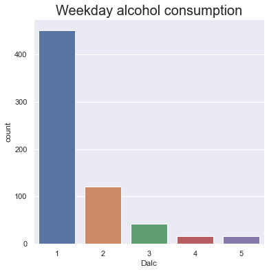

```python
plt.figure(figsize=(6,6))
sns.countplot(x='Dalc',data=data)
plt.title("Weekday alcohol consumption",size=20)
#1 - Wont even touch it , 5 - Alcohol is life
```

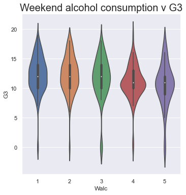

```python
plt.figure(figsize=(12,6))
sns.catplot(x="Walc", y="G3", kind="violin", data=data)
plt.title('Weekend alcohol consumption v G3', size=20)
#1 - Wont even touch it , 5 - Alcohol is life
```

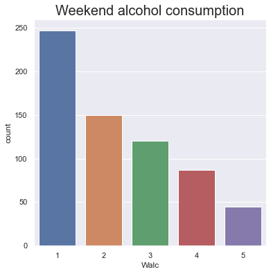

```python
plt.figure(figsize=(6,6))
sns.countplot(x='Walc',data=data)
plt.title("Weekend alcohol consumption",size=20)
#1 - Wont even touch it , 5 - Alcohol is life
```

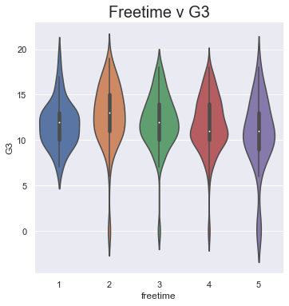

```python
plt.figure(figsize=(12,6))
sns.catplot(x="freetime", y="G3", kind="violin", data=data)
plt.title('Freetime v G3', size=20)
#1 - No free time , 5 - I'm always free
```

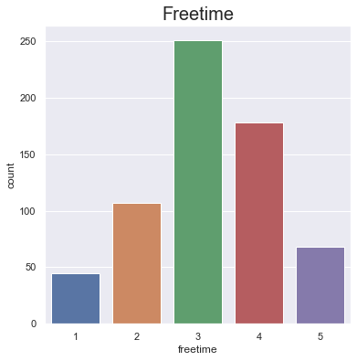

```python
plt.figure(figsize=(6,6))
sns.countplot(x='freetime',data=data)
plt.title("Freetime",size=20)
#1 - No free time , 5 - I'm always free
```

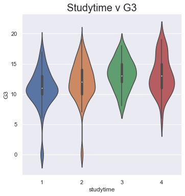

```python
plt.figure(figsize=(12,6))
sns.catplot(x="studytime", y="G3", kind="violin", data=data)
plt.title('Studytime v G3', size=20)
#1 - <2 hours, 2 - 2 to 5 hours, 3 - 5 to 10 hours, or 4 - >10 hours
```

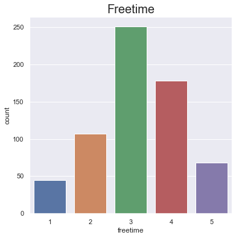

```python
plt.figure(figsize=(6,6))
sns.countplot(x='freetime',data=data)
plt.title("Freetime",size=20)
#1 - Studying once in a blue moon , 5 - I'm always studying
```

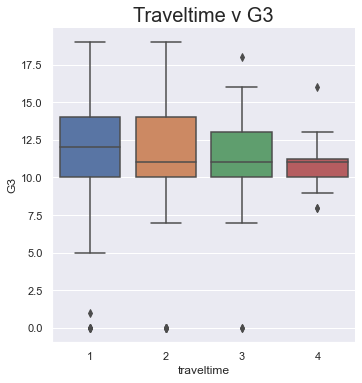

```python
plt.figure(figsize=(12,6))
sns.catplot(x="traveltime", y="G3", kind="box", data=data)
plt.title('Traveltime v G3', size=20)
#1 - I'm very next to school , 5 - I cross seas to study
```

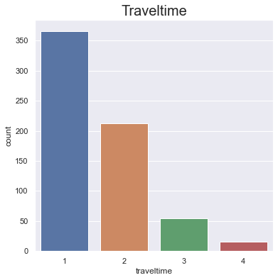

```python
plt.figure(figsize=(6,6))
sns.countplot(x='traveltime',data=data)
plt.title("Traveltime",size=20)
#1 - I'm very next to school , 5 - I cross seas to study
```

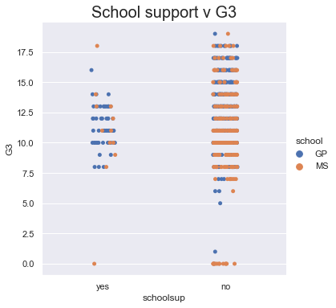

```python
plt.figure(figsize=(12,6))
sns.catplot(x="schoolsup", y="G3", data=data,hue='school')
plt.title('School support v G3', size=20)
```

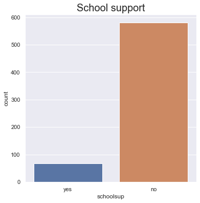

```python
plt.figure(figsize=(6,6))
sns.countplot(x='schoolsup',data=data)
plt.title("School support",size=20)
```

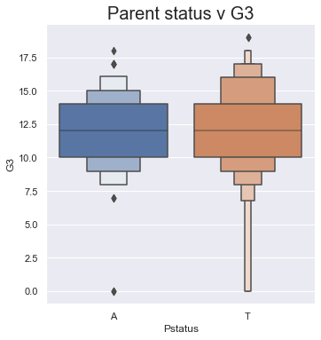

```python
plt.figure(figsize=(12,6))
sns.catplot(x="Pstatus", y="G3", data=data,kind = 'boxen')
plt.title('Parent status v G3', size=20)
#A - Apart , T - Living together
```

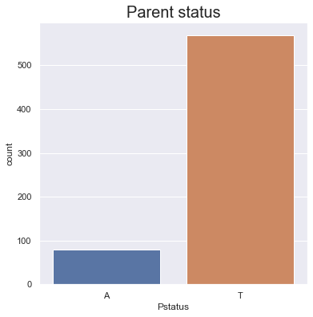

```python
plt.figure(figsize=(6,6))
sns.countplot(x='Pstatus',data=data)
plt.title("Parent status",size=20)
#A - Apart , T - Living together
```

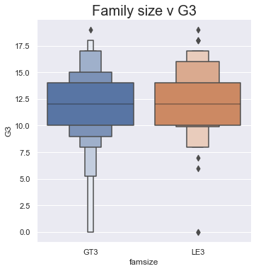

```python
plt.figure(figsize=(12,6))
sns.catplot(x="famsize", y="G3", data=data,kind = 'boxen')
plt.title('Family size v G3', size=20)
# LE3 - less or equal to 3 or GT3 - greater than 3
```

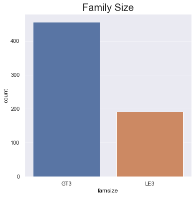

```python
plt.figure(figsize=(6,6))
sns.countplot(x='famsize',data=data)
plt.title("Family Size",size=20)
# LE3 - less or equal to 3 or GT3 - greater than 3
```

# Feature engineering

```python
#Function to OneHotEncode categorical variables using get_dummies

def encode_and_bind(original_dataframe, feature_to_encode):
    dummies = pd.get_dummies(original_dataframe[[feature_to_encode]],drop_first = True)
    res = pd.concat([original_dataframe, dummies], axis=1)
    res = res.drop([feature_to_encode],axis = 1)
    return(res)
```

```python
data.select_dtypes(include=['object']).columns
```

```
Index(['school', 'sex', 'address', 'famsize', 'Pstatus', 'Mjob', 'Fjob',
       'reason', 'guardian', 'schoolsup', 'famsup', 'paid', 'activities',
       'nursery', 'higher', 'internet', 'romantic'],
      dtype='object')
```

```python
features_to_encode = ['school','sex','address','famsize','Pstatus','Mjob','Fjob','reason','guardian','schoolsup','famsup',
                     'paid','activities','nursery','higher','internet','romantic']
for feature in features_to_encode:
    data = encode_and_bind(data, feature)
```

```python
data.shape
```

```
(649, 42)
```

```python
data.columns
```

```
Index(['age', 'Medu', 'Fedu', 'traveltime', 'studytime', 'failures', 'famrel',
       'freetime', 'goout', 'Dalc', 'Walc', 'health', 'absences', 'G1', 'G2',
       'G3', 'school_MS', 'sex_M', 'address_U', 'famsize_LE3', 'Pstatus_T',
       'Mjob_health', 'Mjob_other', 'Mjob_services', 'Mjob_teacher',
       'Fjob_health', 'Fjob_other', 'Fjob_services', 'Fjob_teacher',
       'reason_home', 'reason_other', 'reason_reputation', 'guardian_mother',
       'guardian_other', 'schoolsup_yes', 'famsup_yes', 'paid_yes',
       'activities_yes', 'nursery_yes', 'higher_yes', 'internet_yes',
       'romantic_yes'],
      dtype='object')
```

Feature Scaling and train_test_split

```python
data.describe()
```

|  | age | Medu | Fedu | traveltime | studytime | failures | famrel | freetime | goout | Dalc | Walc | health | absences | G1 | G2 | G3 |
| --- | --- | --- | --- | --- | --- | --- | --- | --- | --- | --- | --- | --- | --- | --- | --- | --- |
| count | 649.000000 | 649.000000 | 649.000000 | 649.000000 | 649.000000 | 649.000000 | 649.000000 | 649.000000 | 649.000000 | 649.000000 | 649.000000 | 649.000000 | 649.000000 | 649.000000 | 649.000000 | 649.000000 |
| mean | 16.744222 | 2.514638 | 2.306626 | 1.568567 | 1.930663 | 0.221880 | 3.930663 | 3.180277 | 3.184900 | 1.502311 | 2.280431 | 3.536210 | 3.659476 | 11.399076 | 11.570108 | 11.906009 |
| std | 1.218138 | 1.134552 | 1.099931 | 0.748660 | 0.829510 | 0.593235 | 0.955717 | 1.051093 | 1.175766 | 0.924834 | 1.284380 | 1.446259 | 4.640759 | 2.745265 | 2.913639 | 3.230656 |
| min | 15.000000 | 0.000000 | 0.000000 | 1.000000 | 1.000000 | 0.000000 | 1.000000 | 1.000000 | 1.000000 | 1.000000 | 1.000000 | 1.000000 | 0.000000 | 0.000000 | 0.000000 | 0.000000 |
| 25% | 16.000000 | 2.000000 | 1.000000 | 1.000000 | 1.000000 | 0.000000 | 4.000000 | 3.000000 | 2.000000 | 1.000000 | 1.000000 | 2.000000 | 0.000000 | 10.000000 | 10.000000 | 10.000000 |
| 50% | 17.000000 | 2.000000 | 2.000000 | 1.000000 | 2.000000 | 0.000000 | 4.000000 | 3.000000 | 3.000000 | 1.000000 | 2.000000 | 4.000000 | 2.000000 | 11.000000 | 11.000000 | 12.000000 |
| 75% | 18.000000 | 4.000000 | 3.000000 | 2.000000 | 2.000000 | 0.000000 | 5.000000 | 4.000000 | 4.000000 | 2.000000 | 3.000000 | 5.000000 | 6.000000 | 13.000000 | 13.000000 | 14.000000 |
| max | 22.000000 | 4.000000 | 4.000000 | 4.000000 | 4.000000 | 3.000000 | 5.000000 | 5.000000 | 5.000000 | 5.000000 | 5.000000 | 5.000000 | 32.000000 | 19.000000 | 19.000000 | 19.000000 |

There's not much scale difference between the features of the data from the observations of mean,std of each feature ... So, Let's skip feature scaling, and proceed to train_test_split

```python
y = data["G3"]
train_data = data.drop(["G3"],axis = 1)
```

```python
train_data.shape,y.shape
```

```
((649, 41), (649,))
```

```python
x_train,x_test,y_train,y_test = train_test_split(train_data,y,test_size = 0.20,random_state = 42)
```

# Model Selection and evaluation

Random Forest Regressor

```python
from sklearn.ensemble import RandomForestRegressor

reg = RandomForestRegressor(max_depth = 25 , random_state = 0)
reg.fit(x_train,y_train)
```

```
RandomForestRegressor(max_depth=25, random_state=0)
```

```python
reg.score(x_train,y_train),reg.score(x_test,y_test)
```

```
(0.9765618707733242, 0.8330849979369432)
```

```python
#Cell to try different set of parameters on the model and get the best parameters

param_dist = {
    'max_depth':[2,5,10,25,50,75,100]
 }
pre_gs_inst = RandomizedSearchCV(RandomForestRegressor(),
 param_distributions = param_dist,
 cv=3,
 n_iter = 10,
 n_jobs=-1)
pre_gs_inst.fit(x_train, y_train)
```

```
RandomizedSearchCV(cv=3, estimator=RandomForestRegressor(), n_jobs=-1,
                   param_distributions={'max_depth': [2, 5, 10, 25, 50, 75,
                                                      100]})
```

```python
#accessing the best_params_ object of the class variable to get the best parameters

pre_gs_inst.best_params_
```

```
{'max_depth': 25}
```

KNN Regressor

```python
from sklearn.neighbors import KNeighborsRegressor

ng = KNeighborsRegressor(n_neighbors=5)

ng.fit(x_train,y_train)
```

```
KNeighborsRegressor()
```

```python
ng.score(x_train,y_train),ng.score(x_test,y_test)
```

```
(0.8683712498227679, 0.7990097327734764)
```

```python
#Cell to try different set of parameters on the model and get the best parameters
param_dist = {
    'n_neighbors':[1,3,5,7,11,17,21,29]
 }
pre_gs_inst = RandomizedSearchCV(KNeighborsRegressor(),
 param_distributions = param_dist,
 cv=3,
 n_iter = 10,
 n_jobs=-1)
pre_gs_inst.fit(x_train, y_train)
```

```
RandomizedSearchCV(cv=3, estimator=KNeighborsRegressor(), n_jobs=-1,
                   param_distributions={'n_neighbors': [1, 3, 5, 7, 11, 17, 21,
                                                        29]})
```

```python
#accessing the best_params_ object of the class variable to get the best parameters

pre_gs_inst.best_params_
```

```
{'n_neighbors': 5}
```

Linear Regression

```python
from sklearn.linear_model import LinearRegression

lreg = LinearRegression()
lreg.fit(x_train,y_train)
```

```
LinearRegression()
```

```python
lreg.score(x_train,y_train),lreg.score(x_test,y_test)
```

```
(0.85833698536359, 0.8486513286537316)
```

SVM Regressor

```python
#Polynomial Kernel

from sklearn.svm import SVR

svr_poly = SVR(kernel='poly', C=200, gamma='auto', degree=2, epsilon=.1,coef0=1)
svr_poly.fit(x_train, y_train)
```

```
SVR(C=200, coef0=1, degree=2, gamma='auto', kernel='poly')
```

```python
svr_poly.score(x_train,y_train),svr_poly.score(x_test,y_test)
```

```
(0.9949880599905225, 0.4626504251057316)
```

```python
#Linear Kernel
svr_lin = SVR(kernel='linear', C=100, gamma='auto')
svr_lin.fit(x_train,y_train)
```

```
SVR(C=100, gamma='auto', kernel='linear')
```

```python
svr_lin.score(x_train,y_train),svr_lin.score(x_test,y_test)
```

```
(0.8442137555984807, 0.8672532517411431)
```

```python
#RBF Kernel
svr_rbf = SVR(kernel='rbf', C=100, gamma=0.003, epsilon=.1)
svr_rbf.fit(x_train,y_train)
```

```
SVR(C=100, gamma=0.003)
```

```python
svr_rbf.score(x_train,y_train),svr_rbf.score(x_test,y_test)
```

```
(0.9090497786767421, 0.852773333343272)
```

Lasso Regression

```python
from sklearn import linear_model

clf = linear_model.Lasso(alpha=0.03)

clf.fit(x_train,y_train)
```

```
Lasso(alpha=0.03)
```

```python
clf.score(x_train,y_train),clf.score(x_test,y_test)
```

```
(0.8512006333361969, 0.8586747930856738)
```

Decision Tree

```python
from sklearn.tree import DecisionTreeRegressor

decTree = DecisionTreeRegressor(min_samples_split = 42)

decTree.fit(x_train,y_train)
```

```
DecisionTreeRegressor(min_samples_split=42)
```

```python
decTree.score(x_train,y_train),decTree.score(x_test,y_test)
```

```
(0.8678460694961754, 0.8005082024364291)
```

XGBoost Regressor

```python
from xgboost import XGBRegressor

model = XGBRegressor()
model = XGBRegressor(n_estimators=1000,reg_lambda = 0.9)
model.fit(x_train,y_train)
```

```
XGBRegressor(base_score=0.5, booster='gbtree', colsample_bylevel=1,
             colsample_bynode=1, colsample_bytree=1, gamma=0, gpu_id=-1,
             importance_type='gain', interaction_constraints='',
             learning_rate=0.300000012, max_delta_step=0, max_depth=6,
             min_child_weight=1, missing=nan, monotone_constraints='()',
             n_estimators=1000, n_jobs=16, num_parallel_tree=1, random_state=0,
             reg_alpha=0, reg_lambda=0.9, scale_pos_weight=1, subsample=1,
             tree_method='exact', validate_parameters=1, verbosity=None)
```

```python
model.score(x_train,y_train),model.score(x_test,y_test)
```

```
(0.9999996989969657, 0.8320022111028647)
```

Polynomial regression

```python
from sklearn.preprocessing import PolynomialFeatures

poly = PolynomialFeatures(2)

x_train_ = poly.fit_transform(x_train)
x_test_  =poly.fit_transform(x_test)

lg = LinearRegression()

lg.fit(x_train_, y_train)
```

```
LinearRegression()
```

```python
lg.score(x_train_,y_train),lg.score(x_test_,y_test)
```

```
(1.0, 0.13364785315275995)
```

AdaBoost

```python
from sklearn.ensemble import AdaBoostRegressor

ada = AdaBoostRegressor(random_state=0, n_estimators=100,learning_rate =0.05,loss="linear")

ada.fit(x_train,y_train)
```

```
AdaBoostRegressor(learning_rate=0.05, n_estimators=100, random_state=0)
```

```python
ada.score(x_train,y_train),ada.score(x_test,y_test)
```

```
(0.873912234934525, 0.8359865290621465)
```

From the above model tests, Linear regression, Lasso regression, AdaBoost, SVR(Linear,Rbf kernel) gave generalized results